# decision_tree

## Decision Tree of League of Legends Winner Prediction

### Methods:

Riot Games created and released League of Legends (also known as LoL), a multiplayer online combat arena game, for Microsoft Windows and macOS. In League of Legends, players take on the role of an invisible "summoner" who commands a "champion" with special skills and engages in combat with a group of other players or champions that are being controlled by computers. Although there are other unique game types available, the objective is often to destroy the opponent team's "nexus," a building that sits at the center of a base secured by defensive structures. All champions in a League of Legends battle start off relatively weak, but as the game progresses, they gain experience and gear that make them stronger. Each League of Legends match is unique.

This section examined League of Legends rated matches and created a decision tree classification method to forecast match results. This algorithm was created by:

Winner (Team1 = 1, Team2 = 2)

Rift Herald, First Baron, Dragon, Tower, Blood, Inhibitor (1 = team1, 2 = team2), and Dragon, Tower, (1 = team2, 2 = team3)

Each team's total number of tower, inhibitor, baron, and dragon deaths

There were features.

Every piece of information came from the previous data gathering that have been cleaned.

[figure not shown]

```python
from IPython import display
display.Image("../HW4/Summoner.jpg")
```

```python
import numpy as np
import pandas as pd
import matplotlib.pyplot as plt

from chart_studio import plotly
from plotly.offline import init_notebook_mode,iplot
init_notebook_mode(connected=True)
import plotly.graph_objs as go

from plotly import tools
import seaborn as sns
import warnings
warnings.filterwarnings("ignore")
import os
```

```python
df = pd.read_csv("../HW4/df_games_clean.csv")

data = df[["winner","firstBlood","firstTower","firstInhibitor","firstBaron","firstDragon","firstRiftHerald","t1_towerKills","t1_inhibitorKills",'t1_baronKills',
       't1_dragonKills','t2_towerKills','t2_inhibitorKills', 't2_baronKills', 't2_dragonKills'
       ]]

data=data.reset_index()
data.drop(["index"],axis=1,inplace=True)

data.head()
```

|  | winner | firstBlood | firstTower | firstInhibitor | firstBaron | firstDragon | firstRiftHerald | t1_towerKills | t1_inhibitorKills | t1_baronKills | t1_dragonKills | t2_towerKills | t2_inhibitorKills | t2_baronKills | t2_dragonKills |
| --- | --- | --- | --- | --- | --- | --- | --- | --- | --- | --- | --- | --- | --- | --- | --- |
| 0 | 1 | 2 | 1 | 1 | 1 | 1 | 2 | 11 | 1 | 2 | 3 | 5 | 0 | 0 | 1 |
| 1 | 1 | 1 | 1 | 1 | 0 | 1 | 1 | 10 | 4 | 0 | 2 | 2 | 0 | 0 | 0 |
| 2 | 1 | 2 | 1 | 1 | 1 | 2 | 0 | 8 | 1 | 1 | 1 | 2 | 0 | 0 | 1 |
| 3 | 1 | 1 | 1 | 1 | 1 | 1 | 0 | 9 | 2 | 1 | 2 | 0 | 0 | 0 | 0 |
| 4 | 1 | 2 | 1 | 1 | 1 | 1 | 0 | 9 | 2 | 1 | 3 | 3 | 0 | 0 | 1 |

### Class Distribution:

Each side wants to safeguard its buildings and demolish the opposition's. Include:

Each lane is protected by towers. Teams have 11 towers.

Each lane has an inhibitor. After destroying the three lane turrets, a team may attack the Inhibitor.

Lower in the river are elder dragons and elemental drakes. Every squad member who kills the drake accumulates buffs throughout the game. Each drake's boost is based on the Four Elements. Six minutes after the last elemental drake is killed, a random one reappears. The Elder Dragon spawns after 35 minutes. It delivers a higher boost than a single elemental drake when killed, however it's transitory.

Rift Herald is a dangerous adversary on the upper riverbank. The Rift Herald may be revived and deployed to attack enemy towers.

Baron Nashor, a neutral antagonist, is on the river's upper bank. It replaces the Rift Herald after 20 minutes.

Each team has a Nexus, which can only be harmed if every turret, inhibitor, and Nexus turrets are downed. Destroying the opponent's Nexus ends the game.

```python
first_team=data[data.winner==1]
second_team=data[data.winner==2]
```

```python
trace1 = go.Histogram(x=first_team.firstBlood, text=['1- First Team', '2- Second Team'],histnorm='probability',marker=dict(color="crimson",line=dict(color='black', width=2)),opacity=0.75)

trace2 = go.Histogram(x=second_team.firstBlood,text=['1- First Team', '2- Second Team'],histnorm='probability',marker=dict(color="blue",line=dict(color='black', width=2)),opacity=0.75)

trace3 = go.Histogram(x=first_team.firstTower,text=['1- First Team', '2- Second Team'],histnorm='probability',marker=dict(color="grey",line=dict(color='black', width=2)),opacity=0.75)

trace4 = go.Histogram(x=second_team.firstTower,text=['1- First Team', '2- Second Team'],histnorm='probability',marker=dict(color="yellow",line=dict(color='black', width=2)),opacity=0.75)

trace5 = go.Histogram(x=first_team.firstBaron,text=['0-None', '1- First Team', '2- Second Team'],histnorm='probability',marker=dict(color="pink",line=dict(color='black', width=2)),opacity=0.75)

trace6 = go.Histogram(x=second_team.firstBaron,text=['0-None', '1- First Team', '2- Second Team'],histnorm='probability',marker=dict(color="green",line=dict(color='black', width=2)),opacity=0.7)

trace7 = go.Histogram(x=first_team.firstInhibitor,text=['0-None', '1- First Team', '2- Second Team'],histnorm='probability',marker=dict(color="purple",line=dict(color='black', width=2)),opacity=0.75)

trace8 = go.Histogram(x=second_team.firstInhibitor,text=['0-None', '1- First Team', '2- Second Team'],histnorm='probability',marker=dict(color="slateblue",line=dict(color='black', width=2)),opacity=0.7)

trace9 = go.Histogram(x=first_team.firstDragon,text=['0-None', '1- First Team', '2- Second Team'],histnorm='probability',marker=dict(color="brown",line=dict(color='black', width=2)),opacity=0.75)

trace10 = go.Histogram(x=second_team.firstDragon,text=['0-None', '1- First Team', '2- Second Team'],histnorm='probability',marker=dict(color="red",line=dict(color='black', width=2)),opacity=0.7)

trace11 = go.Histogram(x=first_team.firstRiftHerald,text=['0-None', '1- First Team', '2- Second Team'],histnorm='probability',marker=dict(color="orange",line=dict(color='black', width=2)),opacity=0.75)

trace12 = go.Histogram(x=second_team.firstRiftHerald,text=['0-None', '1- First Team', '2- Second Team'],histnorm='probability',marker=dict(color="yellowgreen",line=dict(color='black', width=2)),opacity=0.7)

fig = tools.make_subplots(rows=6, cols=2,vertical_spacing=0.1,print_grid=False )

fig.append_trace(trace1, 1, 1)
fig.append_trace(trace2, 1, 2)
fig.append_trace(trace3, 2, 1)
fig.append_trace(trace4, 2, 2)
fig.append_trace(trace5, 3, 1)
fig.append_trace(trace6, 3, 2)
fig.append_trace(trace7, 4, 1)
fig.append_trace(trace8, 4, 2)
fig.append_trace(trace9, 5, 1)
fig.append_trace(trace10, 5, 2)
fig.append_trace(trace11, 6, 1)
fig.append_trace(trace12, 6, 2)
fig['layout'].update( annotations=[dict(showarrow=False,text="Teams",x=0.5,y=-0.1,xref="paper",yref="paper",font=dict(size=15)),dict(showarrow=False, text='Probabilites',x=-0.08,y=0.5,xref="paper",yref="paper",textangle=270,font=dict(size=15)),
                                  dict(showarrow=False,text="First Blood When First Team wins",x=0.13,y=1.03,xref="paper",yref="paper",font=dict(size=10)),
                                  dict(showarrow=False,text="First Blood When Second Team wins",x=0.88,y=1.03,xref="paper",yref="paper",font=dict(size=10)),
                                   dict(showarrow=False,text="First Tower When First Team wins",x=0.13,y=0.85,xref="paper",yref="paper",font=dict(size=10)),
                                  dict(showarrow=False,text="First Tower When Second Team wins",x=0.88,y=0.85,xref="paper",yref="paper",font=dict(size=10)),
                                  dict(showarrow=False,text="First Baron When First Team wins",x=0.13,y=0.65,xref="paper",yref="paper",font=dict(size=10)),
                                  dict(showarrow=False,text="First Baron When Second Team wins",x=0.88,y=0.65,xref="paper",yref="paper",font=dict(size=10)),
                                  dict(showarrow=False,text="First Inhibitor When First Team wins",x=0.13,y=0.46,xref="paper",yref="paper",font=dict(size=10)),
                                  dict(showarrow=False,text="First Inhibitor When Second Team wins",x=0.88,y=0.46,xref="paper",yref="paper",font=dict(size=10)),
                                  dict(showarrow=False,text="First Dragon When First Team wins",x=0.13,y=0.28,xref="paper",yref="paper",font=dict(size=10)),
                                  dict(showarrow=False,text="First Dragon When Second Team wins",x=0.88,y=0.28,xref="paper",yref="paper",font=dict(size=10)),
                                  dict(showarrow=False,text="First Rift Herald When First Team wins",x=0.13,y=0.10,xref="paper",yref="paper",font=dict(size=10)),
                                  dict(showarrow=False,text="First Rift Herald When Second Team wins",x=0.90,y=0.10,xref="paper",yref="paper",font=dict(size=10))],

                     height=800,font=dict(family="Franklin Gothic", size=10),showlegend=False, bargap=0.4,title="Probabilities of First Blood etc. When a Team Wins",plot_bgcolor="snow" ,bargroupgap=0.1, paper_bgcolor='rgb(243, 243, 243)')

iplot(fig)
```

[interactive chart not shown]

Each team's average number of tower, inhibitor, baron, and dragon kills are shown in the table and subplots below.

```python
data_new=data[["winner","t1_towerKills","t1_inhibitorKills","t1_baronKills","t1_dragonKills","t2_towerKills","t2_inhibitorKills","t2_baronKills","t2_dragonKills"]]
data_new.groupby("winner").mean()
```

| winner | t1_towerKills | t1_inhibitorKills | t1_baronKills | t1_dragonKills | t2_towerKills | t2_inhibitorKills | t2_baronKills | t2_dragonKills |
| --- | --- | --- | --- | --- | --- | --- | --- | --- |
| 1 | 8.938945 | 1.920588 | 0.621215 | 2.039726 | 2.703965 | 0.176205 | 0.183246 | 0.850049 |
| 2 | 2.871656 | 0.196167 | 0.162069 | 0.850666 | 8.947318 | 1.910317 | 0.698677 | 2.104700 |

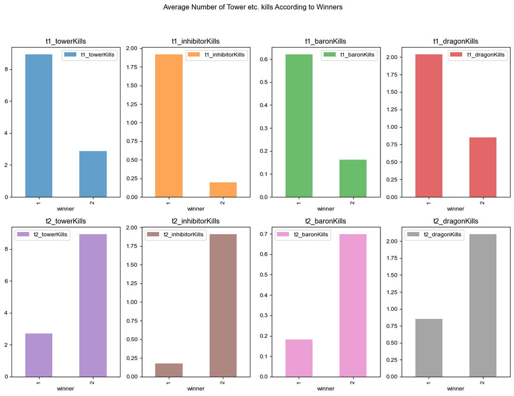

```python
f=data_new.groupby("winner").mean().plot(kind="bar",subplots=True,sharex=False,sharey=False,figsize=(15,10),layout=(2,4),alpha=0.7,title="Average Number of Tower etc. kills According to Winners")
f= sns.set_style("darkgrid")
f=sns.set_context("paper")
plt.show()
```

### Feature Selection:

We looked for the optimal parameters to construct the best model. We utilized the grid search method to discover it.

```python
y = data["winner"].values
x = data.drop(["winner"], axis=1)

from sklearn.model_selection import train_test_split
x_train, x_test, y_train, y_test = train_test_split(x, y, test_size=0.2, random_state=1)

from sklearn.tree import DecisionTreeClassifier
from sklearn.model_selection import GridSearchCV
```

### Model Tuning:

```python
criterion = ["gini", "entropy"]
max_depth = range(1,20,2)
splitter = ["best", "random"]
dt = DecisionTreeClassifier()
grid_decision_tree = GridSearchCV(estimator=dt, cv=15, param_grid=dict(criterion=criterion,max_depth=max_depth,splitter=splitter))
```

```python
grid_decision_tree.fit(x_train, y_train)
```

```
GridSearchCV(cv=15, estimator=DecisionTreeClassifier(),
             param_grid={'criterion': ['gini', 'entropy'],
                         'max_depth': range(1, 20, 2),
                         'splitter': ['best', 'random']})
```

```python
score_df = pd.DataFrame(grid_decision_tree.cv_results_)
score_df.head()
```

|  | mean_fit_time | std_fit_time | mean_score_time | std_score_time | param_criterion | param_max_depth | param_splitter | params | split0_test_score | split1_test_score | ... | split8_test_score | split9_test_score | split10_test_score | split11_test_score | split12_test_score | split13_test_score | split14_test_score | mean_test_score | std_test_score | rank_test_score |
| --- | --- | --- | --- | --- | --- | --- | --- | --- | --- | --- | --- | --- | --- | --- | --- | --- | --- | --- | --- | --- | --- |
| 0 | 0.009036 | 0.000711 | 0.000960 | 0.000080 | gini | 1 | best | {'criterion': 'gini', 'max_depth': 1, 'splitte... | 0.910632 | 0.906394 | ... | 0.913328 | 0.908320 | 0.910632 | 0.909476 | 0.906009 | 0.914484 | 0.909476 | 0.907833 | 0.004802 | 37 |
| 1 | 0.006006 | 0.000650 | 0.000950 | 0.000110 | gini | 1 | random | {'criterion': 'gini', 'max_depth': 1, 'splitte... | 0.884052 | 0.902157 | ... | 0.821263 | 0.828197 | 0.782743 | 0.875578 | 0.895223 | 0.837442 | 0.892142 | 0.865948 | 0.032706 | 40 |
| 2 | 0.019122 | 0.000646 | 0.001243 | 0.000112 | gini | 3 | best | {'criterion': 'gini', 'max_depth': 3, 'splitte... | 0.963020 | 0.961479 | ... | 0.965716 | 0.959553 | 0.963790 | 0.959938 | 0.963790 | 0.962250 | 0.957627 | 0.961685 | 0.002095 | 33 |
| 3 | 0.011341 | 0.000476 | 0.001310 | 0.000115 | gini | 3 | random | {'criterion': 'gini', 'max_depth': 3, 'splitte... | 0.940678 | 0.939137 | ... | 0.942219 | 0.958012 | 0.946456 | 0.953005 | 0.922573 | 0.941063 | 0.887519 | 0.939779 | 0.016806 | 35 |
| 4 | 0.028202 | 0.000835 | 0.001179 | 0.000083 | gini | 5 | best | {'criterion': 'gini', 'max_depth': 5, 'splitte... | 0.976502 | 0.968798 | ... | 0.980740 | 0.966872 | 0.975732 | 0.973035 | 0.969569 | 0.972265 | 0.971109 | 0.972779 | 0.003464 | 14 |

5 rows × 26 columns

```python
score_df.nlargest(5, "mean_test_score")
```

|  | mean_fit_time | std_fit_time | mean_score_time | std_score_time | param_criterion | param_max_depth | param_splitter | params | split0_test_score | split1_test_score | ... | split8_test_score | split9_test_score | split10_test_score | split11_test_score | split12_test_score | split13_test_score | split14_test_score | mean_test_score | std_test_score | rank_test_score |
| --- | --- | --- | --- | --- | --- | --- | --- | --- | --- | --- | --- | --- | --- | --- | --- | --- | --- | --- | --- | --- | --- |
| 26 | 0.030183 | 0.000962 | 0.000944 | 0.000039 | entropy | 7 | best | {'criterion': 'entropy', 'max_depth': 7, 'spli... | 0.979969 | 0.975347 | ... | 0.981895 | 0.974961 | 0.981125 | 0.980740 | 0.973421 | 0.978814 | 0.972265 | 0.977555 | 0.003125 | 1 |
| 6 | 0.034575 | 0.000821 | 0.001203 | 0.000076 | gini | 7 | best | {'criterion': 'gini', 'max_depth': 7, 'splitte... | 0.980740 | 0.974191 | ... | 0.980354 | 0.976888 | 0.979969 | 0.979969 | 0.974191 | 0.978814 | 0.972650 | 0.977196 | 0.002583 | 2 |
| 28 | 0.033596 | 0.000880 | 0.000958 | 0.000019 | entropy | 9 | best | {'criterion': 'entropy', 'max_depth': 9, 'spli... | 0.981895 | 0.977273 | ... | 0.978043 | 0.976502 | 0.981510 | 0.978814 | 0.974191 | 0.979969 | 0.970339 | 0.976708 | 0.003020 | 3 |
| 8 | 0.039604 | 0.001010 | 0.001119 | 0.000093 | gini | 9 | best | {'criterion': 'gini', 'max_depth': 9, 'splitte... | 0.980740 | 0.975347 | ... | 0.980740 | 0.976502 | 0.979199 | 0.979584 | 0.971109 | 0.978428 | 0.970724 | 0.976682 | 0.003010 | 4 |
| 11 | 0.021758 | 0.001374 | 0.001026 | 0.000066 | gini | 11 | random | {'criterion': 'gini', 'max_depth': 11, 'splitt... | 0.978428 | 0.970724 | ... | 0.979584 | 0.972650 | 0.976888 | 0.975732 | 0.971109 | 0.976117 | 0.973035 | 0.975295 | 0.002855 | 5 |

5 rows × 26 columns

```python
print("best score: ", grid_decision_tree.best_score_)
print("best param: ", grid_decision_tree.best_params_)
```

```
best score:  0.9775552131484334
best param:  {'criterion': 'entropy', 'max_depth': 7, 'splitter': 'best'}
```

And we discovered the optimal parameters, including the best splitter and the criteria parameter of entropy. We then put our model to the test.

```python
dt2 = DecisionTreeClassifier(criterion="entropy", max_depth=7, splitter="best")
dt2.fit(x_train, y_train)
print("score: ", dt2.score(x_test, y_test))
```

```
score:  0.9789419619928095
```

About 98% of the time, our model is accurate.

### Baseline Model for Comparison:

While the second team only seized the First Inhibitor, the first team took First Blood, First Tower, First Baron, First Dragon, and First Rift Herald. And

Tower, inhibitor, Baron, and dragon kill totals for Team 1 are 10, 2, 1, and 4, respectively.

Tower, inhibitor, Baron, and dragon kill totals for Team 2 are 7, 2, 1, and 1, respectively.

```python
scenario = {"featrue": ["first_blood","first_tower","first_inhibitor","first_Baron","first_Dragon","first_RiftHerald",
"t1_tower","t1_inhibitor","t1_baron","t1_dragon","t2_tower","t2_inhibitor","t2_baron","t2_dragon"], "value": [1,1,2,1,1,1,10,2,1,4,7,2,1,1]}
scen = pd.DataFrame(scenario)
scen.T
```

|  | 0 | 1 | 2 | 3 | 4 | 5 | 6 | 7 | 8 | 9 | 10 | 11 | 12 | 13 |
| --- | --- | --- | --- | --- | --- | --- | --- | --- | --- | --- | --- | --- | --- | --- |
| featrue | first_blood | first_tower | first_inhibitor | first_Baron | first_Dragon | first_RiftHerald | t1_tower | t1_inhibitor | t1_baron | t1_dragon | t2_tower | t2_inhibitor | t2_baron | t2_dragon |
| value | 1 | 1 | 2 | 1 | 1 | 1 | 10 | 2 | 1 | 4 | 7 | 2 | 1 | 1 |

```python
x1 = [[1,1,2,1,1,1,10,2,1,4,7,2,1,1]]
c = dt2.predict_proba(x1).reshape(-1,1)
print("winner is: ", dt2.predict(x1))
print("first team win probability is:",list(c[0]), "\nsecond team win probability is: ",list(c[1]))
```

```
winner is:  [1]
first team win probability is: [0.9056603773584906]
second team win probability is:  [0.09433962264150944]
```

According to our model, the First Team will win with an 90% likelihood.

### Final Results:

```python
from sklearn import tree
import graphviz
tree_data = tree.export_graphviz(dt2, out_file=None, feature_names=x.columns, class_names=["1","2"], filled=True, rounded=True, special_characters=True)
graph = graphviz.Source(tree_data)
graph
```

[figure not shown]

I utilized a confusion matrix and a classification report to assess our model.

```python
from sklearn.metrics import confusion_matrix, classification_report
predict_values = dt2.predict(x_test)
cm = confusion_matrix(y_test, predict_values)
cr = classification_report(y_test, predict_values)
print("classification report: \n", cr)
```

```
classification report:
               precision    recall  f1-score   support

           1       0.98      0.98      0.98      4953
           2       0.98      0.98      0.98      4782

    accuracy                           0.98      9735
   macro avg       0.98      0.98      0.98      9735
weighted avg       0.98      0.98      0.98      9735
```

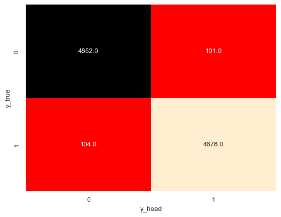

```python
g = sns.heatmap(cm, annot=True, fmt=".1f", cmap="flag", cbar=False)
g.set_xlabel("y_head")
g.set_ylabel("y_true")
```

Our models recognized 101 matches in which the First Team won as the Second Team, as seen in the confusion matrix. It also recognized 104 games in which the Second Team defeated the First Team.

### Conclusion:

Anyway, the decision trees for this part are very quick and effective When campared to KNN and other classification algorithms. Simple to comprehend, interpret, and visualize. Whether the data is numerical, category, or boolean, decision trees can handle any form of data. The Decision Tree does not need normalization. But in the future, this may lead to the model being over-fit on the training set on high-dimensional datasets, overstating the accuracy of predictions on the training set, and preventing the model from properly predicting outcomes on the test set.

For general audience, decision tree can help them to evaluate their options when they play games and predict which team will win when they watch other players. It is an excellent tool for them to choose between several courses of action because it provides a very useful framework within which you may present alternatives and research the potential consequences of those options.